# Cyclistic_Case_Study:Exploratory Data Analysis (EDA) & Visualizations

Sibeso Like

2025-07-16

## Introduction

With a clean and well-structured dataset, the analysis progressed to the exploratory phase to uncover patterns, trends, and differences in usage behavior between casual riders and annual members. Through a combination of SQL queries and visualizations created in R, key insights were generated on ride duration, day-of-week preferences, peak usage hours, and station activity. These findings laid the groundwork for data-driven recommendations aimed at helping Cyclistic convert more casual users into loyal annual members.

The insights were generated by analyzing seven aspects of the dataset as follows:

- Total Rides by User Type
- Ride Duration by User type
- Ride Volume by Day of Week
- Ride Volume by Hour of Day
- Ride Volume by Rideable Type
- Top Start Stations
- Top End Stations

## Visualizations - (Created using Rstudio)

### 1. Total Rides by User Type

**Code for creating the Visual**

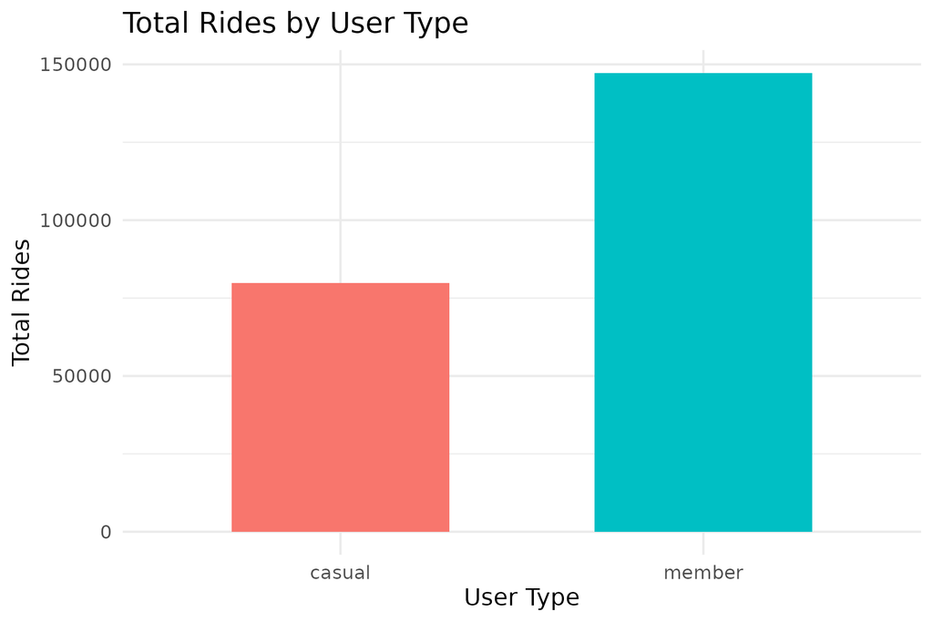

Figure 1: Total rides comparison between user types

```r
user_type_plot <- ggplot(eda_rides_by_user_type, aes(x = member_casual, y = total_rides, fill = member_casual)) +
  geom_bar(stat = "identity", width = 0.6) +
  labs(
    title = "Total Rides by User Type",
    x = "User Type",
    y = "Total Rides"
  ) +
  theme_minimal() +
  theme(legend.position = "none")  # Hide legend since it's already labeled
```

**Key Conclusions:**

Members take significantly more rides than casual users- almost double. This may suggest daily/commuter usage by members vs occasional use by casual riders.

### 2. Ride Duration by User Type

**R Code for the visualization**

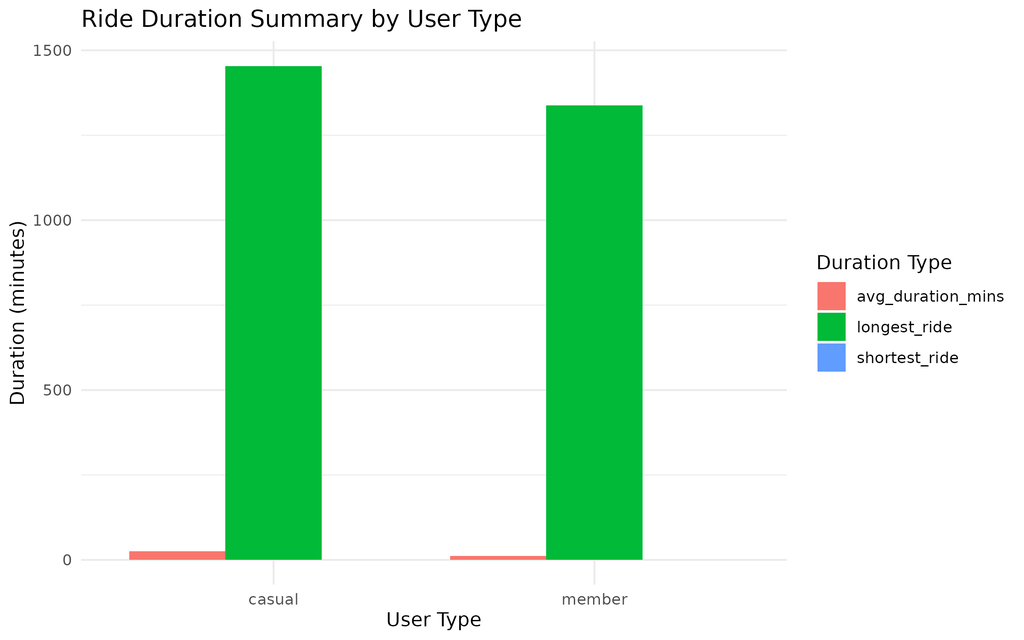

Figure 2: Comparison of average, minimum, and maximum trip durations by user type

```r
duration_plot <- ggplot(eda_duration_long, aes(x = user_type, y = duration_minutes, fill = duration_type)) +
  geom_bar(stat = "identity", position = position_dodge()) +
  labs(
    title = "Ride Duration Summary by User Type",
    x = "User Type",
    y = "Duration (minutes)",
    fill = "Duration Type"
  ) +
  theme_minimal()
```

**Key Conclusions:**

- Casual riders take longer trips on average (25 minutes) compared to members (12 minutes), indicating they may use bikes more for leisure or exploration rather than commuting.
- Both groups have a minimum trip duration of 1 minute, possibly representing very short rides, test runs, or mistaken rentals.
- Maximum trip durations are higher for casuals (1,454 minutes) than for members (1,338 minutes), further reinforcing the idea that casuals are less time-sensitive and possibly less cost-conscious.
- This significant difference in average trip duration is a clear behavioral distinction that Cyclistic could leverage to design personalized user experiences or targeted promotions.